# PROTAC linker enumeration

# Custom linker composition

## Case-1

```python
methyl_part = generate_methyl_linker(num=2) # Part-1
peg_part = generate_peg_linker(num=2) # Part-3
```

```python
piperidine = Chem.MolFromSmiles('*-N1CCN(-*)CC1 ') # Part-2
PROTAC_lib = []
for i in range(2):
    for Li in LIGASE:
        linker = combine_frags(methyl_part[i],piperidine) # Combine part-1 and part-2
        linker = combine_frags(linker,peg_part[i]) # Combine part-3
        protac_temp = combine_frags(target,linker) # Combine target ligand and linker
        protac_temp = combine_frags(protac_temp,Li) # Combine target-linker to ligase ligand
        PROTAC_lib.append([Chem.MolToSmiles(target),Chem.MolToSmiles(Li),Chem.MolToSmiles(linker),Chem.MolToSmiles(protac_temp)])
PROTAC_DICT = pd.DataFrame(columns=['target','ligase','linker','protac'])
for i in PROTAC_lib:
    TEMP_DICT = pd.DataFrame(dict(zip(['target','ligase','linker','protac'],i)),index=[0])
    PROTAC_DICT = pd.concat([PROTAC_DICT,TEMP_DICT], ignore_index=True)
PROTAC_DICT
```

|  | target | ligase | linker | protac |
| --- | --- | --- | --- | --- |
| 0 | *NC(=O)C[C@@H]1N=C(c2ccc(Cl)cc2)c2c(sc(C)c2C)-... | *C(=O)N[C@H](C(=O)N1C[C@H](O)C[C@H]1C(=O)NCc1c... | *CN1CCN(OCCO*)CC1 | CC1=C(c2ccc(CNC(=O)[C@@H]3C[C@@H](O)CN3C(=O)[C... |
| 1 | *NC(=O)C[C@@H]1N=C(c2ccc(Cl)cc2)c2c(sc(C)c2C)-... | *NC(=O)COc1cccc2c1C(=O)N([C@H]1CCC(=O)NC1=O)C2=O | *CN1CCN(OCCO*)CC1 | Cc1sc2c(c1C)C(c1ccc(Cl)cc1)=N[C@@H](CC(=O)NCN1... |
| 2 | *NC(=O)C[C@@H]1N=C(c2ccc(Cl)cc2)c2c(sc(C)c2C)-... | *C(=O)N[C@H](C(=O)N1C[C@H](O)C[C@H]1C(=O)NCc1c... | *CCN1CCN(OCCOCCO*)CC1 | CC1=C(c2ccc(CNC(=O)[C@@H]3C[C@@H](O)CN3C(=O)[C... |
| 3 | *NC(=O)C[C@@H]1N=C(c2ccc(Cl)cc2)c2c(sc(C)c2C)-... | *NC(=O)COc1cccc2c1C(=O)N([C@H]1CCC(=O)NC1=O)C2=O | *CCN1CCN(OCCOCCO*)CC1 | Cc1sc2c(c1C)C(c1ccc(Cl)cc1)=N[C@@H](CC(=O)NCCN... |

target

ligase

linker

protac

0

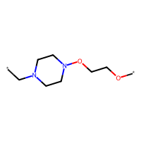

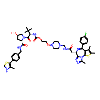

1

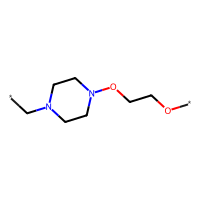

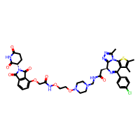

2

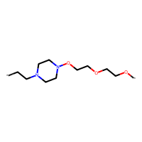

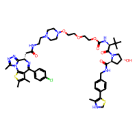

3

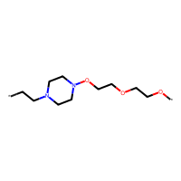

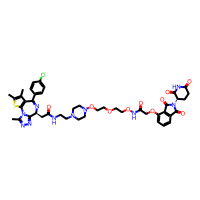

```python
from rdkit.Chem import PandasTools
import pandas as pd
from IPython.core.display import HTML

PandasTools.AddMoleculeColumnToFrame(PROTAC_DICT, smilesCol='target', molCol='target')
PandasTools.AddMoleculeColumnToFrame(PROTAC_DICT, smilesCol='ligase', molCol='ligase')
PandasTools.AddMoleculeColumnToFrame(PROTAC_DICT, smilesCol='linker', molCol='linker')
PandasTools.AddMoleculeColumnToFrame(PROTAC_DICT, smilesCol='protac', molCol='protac')

PandasTools.RenderImagesInAllDataFrames(images=True)
HTML(PROTAC_DICT.to_html(notebook=True))
```

## Case-2

Now we will create a custom linker composition with linker composed of three parts part-1 (2 methyl), part-2 (1 peg) and part-3 (1 methyl) which be linked to the target and ligase.

target - (methyl)2 - (peg)1 - (methyl)1 - ligase

```python
# Generate the custom linker

methyl_part = generate_polymer(Chem.MolFromSmiles('*-C-*'),num=2,del_atoms=1) #Part-1 which contains two methyl
peg_part = generate_polymer(Chem.MolFromSmiles('*-OCCO-*'),num=1,del_atoms=2) # Part-2 of one peg
methyl_part2 = generate_polymer(Chem.MolFromSmiles('*-C-*'),num=1,del_atoms=1) # Part-3 of one methyl

linker = combine_frags(methyl_part, peg_part) # Combine part-1 and part-2
linker = combine_frags(linker, methyl_part2)  # Combine part-3

linker
```

[figure not shown]

```python
# Combine the linker with target and ligase ligand
protac = combine_frags(target,linker)
protac = combine_frags(protac,LIGASE[0]) # VHL ligase ligand
protac
```

[figure not shown]

References:

[1] Current strategies for the design of PROTAC linkers: a critical review. doi: Current strategies for the design of PROTAC linkers: a critical review. DOI: https://doi.org/10.37349/etat.2020.00018

[2] Computer aided drug design in the development of proteolysis targeting chimeras. DOI: https://doi.org/10.1016/j.csbj.2023.02.042